# 2.3 Transformación del parámetro

Supongamos que ahora buscamos hacer inferencia del parámetro $\tau=log(\sigma)$, ¿cuál es el estimador de máxima verosimilitud?

Al calcular analíticamente la función de log verosimilitud se considera la likelihood y prior de las funciones. De esta forma:

La normal sigue la siguiente distribución con su respectiva likelihood:
$$f(x) = \frac{1}{\sqrt{2\pi \sigma^2}} \exp\Bigg(\frac{1}{2\sigma^2}(x -\mu)^2\Bigg) \\
L(x) = \frac{1}{ ( 2\pi \sigma^2)^{n/2}} \exp(\frac{1}{2\sigma^2}\sum_i(x_i -\mu)^2)$$

De manera que, dada una muestra $x_1, x_2, x_3, ..., x_n$, y substituyendo $a = log(\sigma)$ de tal forma que $\sigma^2 = e^{2a}$ tenemos que la log likelihood la podemos expresar de la siguiente manera:
$$l(x) = -\frac{n}{2} log(2\pi) - \frac{n}{2}log(e^{2log \sigma}) - \frac{1}{2 e^{2 log \sigma}}\sum_i (x_i-\mu)^2 \\
l(x) = -\frac{n}{2} log(2\pi) - \frac{n}{2}log(e^{2a}) - \frac{1}{2e^{2a}}\sum_i (x_i-\mu)^2$$
Al derivarparcialmente con respecto $a$ e igualando a 0, obtenemos la siguiente expresión:
$$\frac{\partial l(x)}{\partial a} = - \frac{n 2 e^{2a}}{2 e^{2a}} - \Bigg[ \frac{1}{2}\sum_i (x_i-\mu)^2 \Bigg]\Bigg[ -\frac{2}{e^{2a}} \Bigg] \\
= -n + \Bigg[ \frac{1}{e^{2a}}\sum_i (x_i-\mu)^2 \Bigg] \\
\Rightarrow \Bigg[ \frac{1}{e^{2a}}\sum_i (x_i-\mu)^2 \Bigg] = n\\
\Rightarrow \frac{\sum_i (x_i-\mu)^2}{{n}} = e^{2a}\\
\Rightarrow \frac{\sum_i (x_i-\mu)^2}{{n}} = e^{2a}\\
\Rightarrow a = \log{\sqrt{\frac{\sum_i (x_i-\mu)^2}{n}}}\\$$
Como $a = log(\sigma)$, entonces tenemos que $\hat{log(\sigma)} = \log{\sqrt{\frac{\sum_i (x_i-\mu)^2}{n}}}$ siendo el último el estimador MLE.

Este resultado es congruente con la propiedad de los MLE vista en clase, en particular el teorema de equivarianza de los MLE:

Sea $\tau = g(\theta)$ una función de $\theta$ bien comportada. Entonces si $\hat{\theta_n}$ es el MLE de $\theta$, entonces $\hat{\tau_n} = g(\hat{\theta_n})$ es el MLE de $\tau$, ya que aplicando directamente el teorema obtenemos el mismo resultado.

Para encontrarla con la función *optim* como vimos en clase, en lugar de analíticamente, hacemos uso de la funcion crear_log_p. Esta funcion nos ayuda a generar las funciones log_p.

```r
library(tidyverse)
# La función crear_log_p crea una funcion llamada log_p que recibe dos parámetros (media, sigma) tal que se estandariza la funcion y se calcula su respectiva log verosimilitud
crear_log_p <- function(x){
  log_p <- function(pars){
    media = pars[1]
    log_sigma = pars[2]
    z <- (x - media) / exp(log_sigma)
    log_verosim <- -(log_sigma +  0.5 * mean(z^2))
    log_verosim
  }
  log_p
}
```

Con esto procedemos a cargar los datos y optimizarlo con la función optim:

```r
load("data/x.RData")
muestra <- x

log_p <- crear_log_p(muestra)

res <-
  optim(
    par = c(0, 0.5),
    fn = log_p,
    control = list(fnscale = -1, maxit = 10000),
    method = "Nelder-Mead"
    )

est_mle <-
  tibble(
    parametro = c("media", "log-sigma"),
    estimador = res$par
    ) %>%
  column_to_rownames(var = "parametro")

est_mle
```

```
##           estimador
## media     0.5605653
## log-sigma 2.4372931
```

al compararlo con el resultado anterior (es decir, el de sigma sin la transformación) tenemos que es equivalente a aplicar el logaritmo a $\sigma$. Para el aproximar el error estándar usando boostrap paramétrico hacemos uso de las funciones generadas en clase (con sus respectivas modificaciones)

```r
# simular_modelo encuentra n número de observaciones de una distribución normal con la media y sigma proporcionada
simular_modelo <- function(n, media, log_sigma){
  rnorm(n, media, exp(log_sigma))
}
```

```r
# la función rep_boot repite
rep_boot <- function(rep, crear_log_p, est_mle, n){
  muestra_bootstrap <-
    simular_modelo(
      n = length(muestra),
      media = est_mle["media", "estimador"],
      log_sigma = est_mle["log-sigma", "estimador"]
      )

  log_p_boot <- crear_log_p(muestra_bootstrap)

  # optimizamos

  res_boot <-
    optim(
      par = c(0, 0.5),
      fn = log_p_boot,
      control = list(fnscale = -1, maxit = 1000),
      method = "Nelder-Mead"
      )

  try(if(res_boot$convergence != 0) stop("No se alcanzó convergencia."))
  tibble(parametro = c("media", "log-sigma"), estimador_boot = res_boot$par)
}
```

```r
reps_boot <- map_dfr(
  .x = 1:5000,
  .f = ~ rep_boot(.x, crear_log_p, est_mle, n = length(muestra)),
  rep = ".id"
  )

reps_boot %>% nrow()
```

```
## [1] 10000
```

```r
error_est <-
  reps_boot %>%
  group_by(parametro) %>%
  summarise(ee_boot = sd(estimador_boot))
bind_cols(est_mle, error_est) %>%
  mutate(across(where(is.numeric), round, 3)) %>%
  select(parametro, estimador, ee_boot)
```

```
##   parametro estimador ee_boot
## 1 log-sigma     0.561   0.058
## 2     media     2.437   0.945
```

Mostrando el histograma tanto de sigma como de la media:

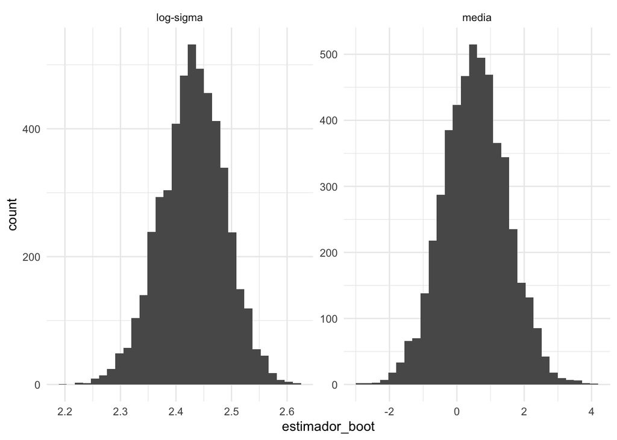

```r
reps_boot %>%
  ggplot(aes(x = estimador_boot)) +
  geom_histogram()+
  facet_wrap(~parametro, scales = "free")+
  theme_minimal()
```

- Ahora volvamos a inferencia bayesiana, calcula un intervalo de confianza para $\tau$ y un histograma de la distribución posterior de $\tau$.